# Pharmaceutical Dataset

2024-03-16

# Step 1: Importing The Dataset in R

```r
# Loading the necessary libraries
library(tidyverse)
```

```r
library(ggplot2)

#The data can be imported in R using the function read.csv()
library(readr)
pharma_data<-read.csv("~/Downloads/Pharmaceuticals (1).csv")

# head() function is used to understand the content in the dataset.
head(pharma_data)
```

```
##   Symbol                Name Market_Cap Beta PE_Ratio  ROE  ROA Asset_Turnover
## 1    ABT Abbott Laboratories      68.44 0.32     24.7 26.4 11.8            0.7
## 2    AGN      Allergan, Inc.       7.58 0.41     82.5 12.9  5.5            0.9
## 3    AHM        Amersham plc       6.30 0.46     20.7 14.9  7.8            0.9
## 4    AZN     AstraZeneca PLC      67.63 0.52     21.5 27.4 15.4            0.9
## 5    AVE             Aventis      47.16 0.32     20.1 21.8  7.5            0.6
## 6    BAY            Bayer AG      16.90 1.11     27.9  3.9  1.4            0.6
##   Leverage Rev_Growth Net_Profit_Margin Median_Recommendation Location Exchange
## 1     0.42       7.54              16.1          Moderate Buy       US     NYSE
## 2     0.60       9.16               5.5          Moderate Buy   CANADA     NYSE
## 3     0.27       7.05              11.2            Strong Buy       UK     NYSE
## 4     0.00      15.00              18.0         Moderate Sell       UK     NYSE
## 5     0.34      26.81              12.9          Moderate Buy   FRANCE     NYSE
## 6     0.00      -3.17               2.6                  Hold  GERMANY     NYSE
```

```r
# str() function is used to understand the structure in the dataset.
str(pharma_data)
```

```
## 'data.frame':    21 obs. of  14 variables:
##  $ Symbol               : chr  "ABT" "AGN" "AHM" "AZN" ...
##  $ Name                 : chr  "Abbott Laboratories" "Allergan, Inc." "Amersham plc" "AstraZeneca PLC" ...
##  $ Market_Cap           : num  68.44 7.58 6.3 67.63 47.16 ...
##  $ Beta                 : num  0.32 0.41 0.46 0.52 0.32 1.11 0.5 0.85 1.08 0.18 ...
##  $ PE_Ratio             : num  24.7 82.5 20.7 21.5 20.1 27.9 13.9 26 3.6 27.9 ...
##  $ ROE                  : num  26.4 12.9 14.9 27.4 21.8 3.9 34.8 24.1 15.1 31 ...
##  $ ROA                  : num  11.8 5.5 7.8 15.4 7.5 1.4 15.1 4.3 5.1 13.5 ...
##  $ Asset_Turnover       : num  0.7 0.9 0.9 0.9 0.6 0.6 0.9 0.6 0.3 0.6 ...
##  $ Leverage             : num  0.42 0.6 0.27 0 0.34 0 0.57 3.51 1.07 0.53 ...
##  $ Rev_Growth           : num  7.54 9.16 7.05 15 26.81 ...
##  $ Net_Profit_Margin    : num  16.1 5.5 11.2 18 12.9 2.6 20.6 7.5 13.3 23.4 ...
##  $ Median_Recommendation: chr  "Moderate Buy" "Moderate Buy" "Strong Buy" "Moderate Sell" ...
##  $ Location             : chr  "US" "CANADA" "UK" "UK" ...
##  $ Exchange             : chr  "NYSE" "NYSE" "NYSE" "NYSE" ...
```

# Step 2: Checking For Missing Values in The Dataset

```r
#Descriptive Statistics
summary(pharma_data)
```

```
##     Symbol              Name             Market_Cap          Beta
##  Length:21          Length:21          Min.   :  0.41   Min.   :0.1800
##  Class :character   Class :character   1st Qu.:  6.30   1st Qu.:0.3500
##  Mode  :character   Mode  :character   Median : 48.19   Median :0.4600
##                                        Mean   : 57.65   Mean   :0.5257
##                                        3rd Qu.: 73.84   3rd Qu.:0.6500
##                                        Max.   :199.47   Max.   :1.1100
##     PE_Ratio          ROE            ROA        Asset_Turnover    Leverage
##  Min.   : 3.60   Min.   : 3.9   Min.   : 1.40   Min.   :0.3    Min.   :0.0000
##  1st Qu.:18.90   1st Qu.:14.9   1st Qu.: 5.70   1st Qu.:0.6    1st Qu.:0.1600
##  Median :21.50   Median :22.6   Median :11.20   Median :0.6    Median :0.3400
##  Mean   :25.46   Mean   :25.8   Mean   :10.51   Mean   :0.7    Mean   :0.5857
##  3rd Qu.:27.90   3rd Qu.:31.0   3rd Qu.:15.00   3rd Qu.:0.9    3rd Qu.:0.6000
##  Max.   :82.50   Max.   :62.9   Max.   :20.30   Max.   :1.1    Max.   :3.5100
##    Rev_Growth    Net_Profit_Margin Median_Recommendation   Location
##  Min.   :-3.17   Min.   : 2.6      Length:21             Length:21
##  1st Qu.: 6.38   1st Qu.:11.2      Class :character      Class :character
##  Median : 9.37   Median :16.1      Mode  :character      Mode  :character
##  Mean   :13.37   Mean   :15.7
##  3rd Qu.:21.87   3rd Qu.:21.1
##  Max.   :34.21   Max.   :25.5
##    Exchange
##  Length:21
##  Class :character
##  Mode  :character
##
##
##
```

```r
# Counting the number of missing values in the entire dataset
total_missing_values <- sum(is.na(pharma_data))

# Counting NA values in each column of the dataset
missing_values_per_column <- colSums(is.na(pharma_data))

# Printing the counts of missing values for each column
print(missing_values_per_column)
```

```
##                Symbol                  Name            Market_Cap
##                     0                     0                     0
##                  Beta              PE_Ratio                   ROE
##                     0                     0                     0
##                   ROA        Asset_Turnover              Leverage
##                     0                     0                     0
##            Rev_Growth     Net_Profit_Margin Median_Recommendation
##                     0                     0                     0
##              Location              Exchange
##                     0                     0
```

# Step 3:Preprocessing The Data: Selecting the Numerical Variables

```r
# Select only the numerical variables
numerical_indices <- c(3, 4, 5, 6, 7, 8, 9, 10, 11)
pharma_data_prepared <- pharma_data[, numerical_indices]
pharma_data_prepared
```

```
##    Market_Cap Beta PE_Ratio  ROE  ROA Asset_Turnover Leverage Rev_Growth
## 1       68.44 0.32     24.7 26.4 11.8            0.7     0.42       7.54
## 2        7.58 0.41     82.5 12.9  5.5            0.9     0.60       9.16
## 3        6.30 0.46     20.7 14.9  7.8            0.9     0.27       7.05
## 4       67.63 0.52     21.5 27.4 15.4            0.9     0.00      15.00
## 5       47.16 0.32     20.1 21.8  7.5            0.6     0.34      26.81
## 6       16.90 1.11     27.9  3.9  1.4            0.6     0.00      -3.17
## 7       51.33 0.50     13.9 34.8 15.1            0.9     0.57       2.70
## 8        0.41 0.85     26.0 24.1  4.3            0.6     3.51       6.38
## 9        0.78 1.08      3.6 15.1  5.1            0.3     1.07      34.21
## 10      73.84 0.18     27.9 31.0 13.5            0.6     0.53       6.21
## 11     122.11 0.35     18.0 62.9 20.3            1.0     0.34      21.87
## 12       2.60 0.65     19.9 21.4  6.8            0.6     1.45      13.99
## 13     173.93 0.46     28.4 28.6 16.3            0.9     0.10       9.37
## 14       1.20 0.75     28.6 11.2  5.4            0.3     0.93      30.37
```

[output cut: 29 more lines]

# Step 4: Normalizing The Data

```r
pharma_data_normalized <- as.data.frame(scale(pharma_data_prepared))
```

# Step 5: Determining The Number of Clusters

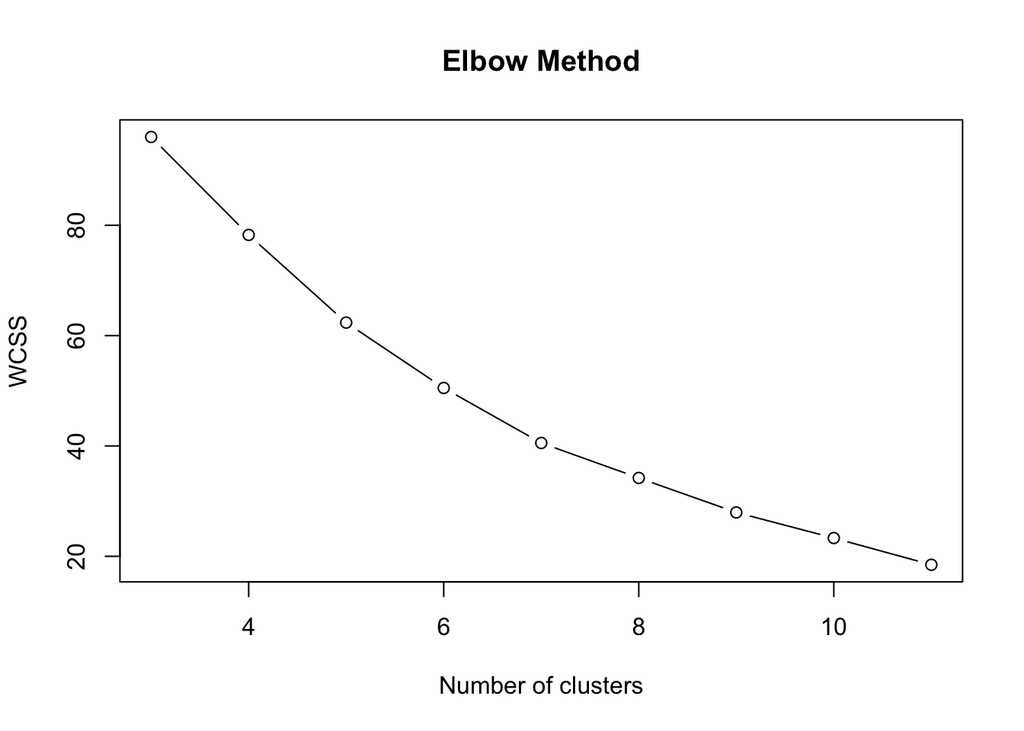

```r
wcss <- sapply(3:11, function(k) {kmeans(pharma_data_normalized, k, nstart = 11)$tot.withinss})

# Plotting the elbow method results
plot(3:11, wcss, type='b', main='Elbow Method', xlab='Number of clusters', ylab='WCSS')
```

# Step 6: Clustering With k-Means

```r
# Replacing k with the chosen number of clusters
set.seed(123)
k <- 3 #Assuming 3 is the optimal number of clusters
km_result <- kmeans(pharma_data_normalized, centers = k, nstart = 25)

# Adding the cluster assignments to the original dataset
pharma_data$Cluster <- km_result$cluster

# Analyzing the financial structure of the pharmaceutical industry based on the clusters
cluster_means <- aggregate(. ~ pharma_data$Cluster, data=pharma_data_normalized, FUN=mean)
print(cluster_means)
```

```
##   pharma_data$Cluster Market_Cap       Beta   PE_Ratio        ROE        ROA
## 1                   1 -0.6125361  0.2698666  1.3143935 -0.9609057 -1.0174553
## 2                   2  0.6733825 -0.3586419 -0.2763512  0.6565978  0.8344159
## 3                   3 -0.8261772  0.4775991 -0.3696184 -0.5631589 -0.8514589
##   Asset_Turnover   Leverage Rev_Growth Net_Profit_Margin
## 1      0.2306328 -0.3592866 -0.5757385        -1.3784169
## 2      0.4612656 -0.3331068 -0.2902163         0.6823310
## 3     -0.9994088  0.8502201  0.9158889        -0.3319956
```

# Step 7: Analysing And Interpreting The Clusters

```r
# Summary statistics for each cluster
aggregate(pharma_data_prepared, by=list(pharma_data$Cluster), FUN=mean)
```

```
##   Group.1 Market_Cap      Beta PE_Ratio  ROE       ROA Asset_Turnover  Leverage
## 1       1   21.75500 0.5950000 46.90000 11.3  5.100000      0.7500000 0.3050000
## 2       2   97.11364 0.4336364 20.95455 35.7 14.954545      0.8000000 0.3254545
## 3       3    9.23500 0.6483333 19.43333 17.3  5.983333      0.4833333 1.2500000
##   Rev_Growth Net_Profit_Margin
## 1    7.01000           6.65000
## 2   10.16455          20.17273
## 3   23.49000          13.51667
```

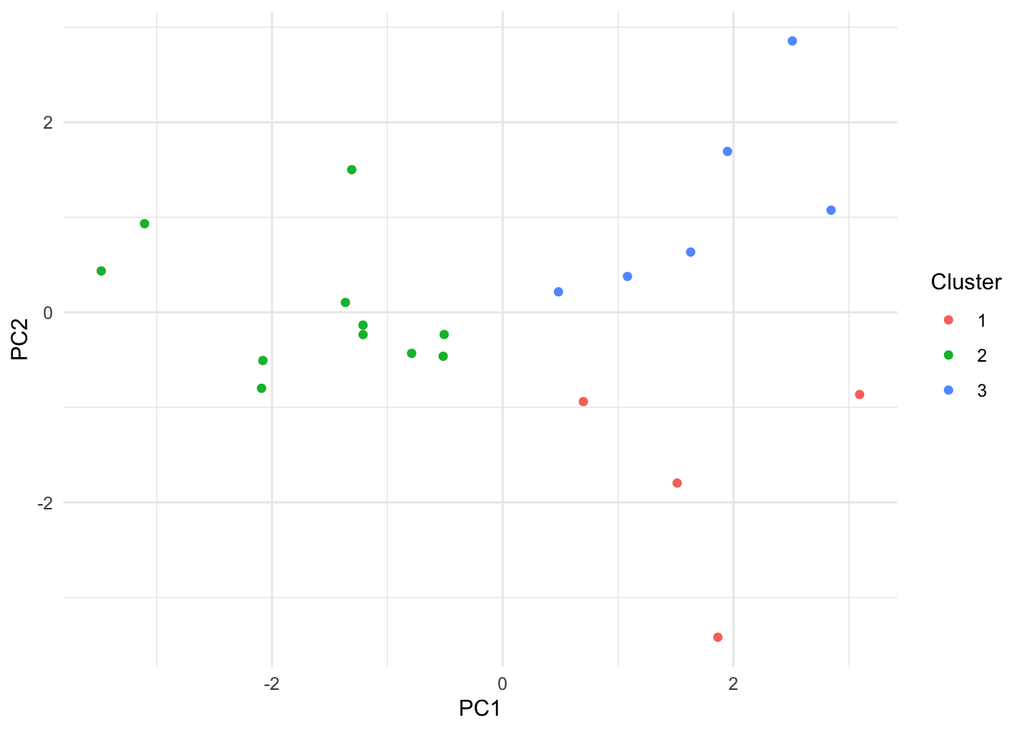

```r
# Visualizing clusters (example using PCA for dimensionality reduction)
library(ggplot2)
pca_res <- prcomp(pharma_data_normalized)
pca_data <- data.frame(pca_res$x[,1:2], Cluster=pharma_data$Cluster)

ggplot(pca_data, aes(x=PC1, y=PC2, color=as.factor(Cluster))) +
  geom_point() +
  theme_minimal() +
  labs(color="Cluster")
```

#Cluster 1:

#Cluster 2:

#The largest companies by market capitalization, implying dominance in the industry.Less volatile, indicating stability.More attractively valued with lower P/E ratios, suggesting they’re seen as solid investments.Highly efficient, with the best use of equity and assets to generate profits.Good revenue generation capability, moderate leverage, and the highest profitability, indicating strong financial health.

#Cluster 3:

#Smallest by market capitalization, suggesting younger or more niche companies.The most volatile, with the highest Beta, indicating higher market risk.Moderate valuation and efficiency in using equity and assets compared to the other clusters.Aggressive growth strategy as evidenced by the highest revenue growth and high leverage.Moderate profitability, which is respectable considering their aggressive expansion

#Through the analysis of financial performance, it is possible to derive insights regarding the pharmaceutical industry’s structure as well as the comparative strengths and weaknesses of the companies that operate within it.This can help us decide where to spend our money or come up with ways to compete in the market.